# Final_Report_Complete

```python
from IPython.display import display, HTML

display(HTML("""
<div style="
    display: flex;
    flex-direction: column;
    justify-content: center;
    align-items: center;
    height: 90vh;
    text-align: center;
">
    <h1 style="margin-bottom: 40px;">
        Final Project - Predicting Youtube Virality
    </h1>
    <p style="font-size: 18px; margin-bottom: 80px;">
        Content Creator Attributes
    </p>
    <p style="font-size: 16px; margin-bottom: 40px;">
        Max Chalekson, Eddie Deng, Selin Altiparmak
    </p>
    <p style="font-size: 16px; margin-bottom: 10px;">
        Week 8 – MSDS 422
    </p>
    <p style="font-size: 16px; margin-bottom: 80px;">
        Practical Machine Learning
    </p>
    <p style="font-size: 16px;">
        February 2026
    </p>
</div>
"""))
```

Final Project - Predicting Youtube Virality

Content Creator Attributes

Max Chalekson, Eddie Deng, Selin Altiparmak

Week 8 – MSDS 422

Practical Machine Learning

February 2026

# MSDS 422 Final Project — Integrated Final Report Notebook

## Predicting YouTube Video Virality Using Content, Creator, and Engagement Attributes

This notebook is the unified final deliverable for executive and technical audiences. It includes:

- Full final report narrative (English)
- Complete methodology, assumptions, and model evaluation details
- Chicago author-date style references
- Aggregated project code from all core notebooks:
  1. `YT-pipeline.ipynb`
  2. `EDA.ipynb`
  3. `EDA_enriched_API.ipynb`
  4. `modeling_4_models.ipynb`

> Note: Some code blocks (especially API enrichment and image processing) may require local environment variables, valid API credentials, and sufficient runtime resources.

## Final Report (Executive + Technical)

# MSDS 422 Final Project — Final Report

## Predicting YouTube Video Virality Using Content, Creator, and Engagement Attributes

**Team:** Selin Altiparmak, Max Chalekson, Eddie Deng  
**Course:** MSDS 422 – Machine Learning  
**Dataset:** YouTube Videos Data for ML and Trend Analysis (Kaggle)

## 1. Executive Summary

This project delivers an end-to-end machine learning pipeline to predict YouTube video virality using a multi-view feature set: content metadata, technical/video properties, creator/channel attributes, and optional thumbnail-derived visual proxies. The workflow integrates data enrichment via the YouTube Data API, exploratory analysis, feature engineering, and the training and evaluation of four ML models (Elastic Net, K-Nearest Neighbors, Random Forest, and Multi-Layer Perceptron). The **tuned Random Forest** emerged as the best-performing model, explaining approximately **62% of the variance** in log-transformed view counts (RMSE = 1.507, R² = 0.621). Key findings indicate that **creator-level social capital**—subscriber count, channel view history, and channel average views per video—is the strongest predictor of views, with thumbnail brightness and colorfulness providing secondary but measurable signal. The analysis deliberately avoids using likes and comments as predictors when predicting views to prevent target leakage and to support **pre- or early-post-publication** use cases. The report is structured for an executive audience and concludes with model comparison, business impact considerations, lessons learned, and recommendations including deployment strategy, next steps, and third-party data sources that could add value.

## 2. Problem Statement / Research Objectives

### Problem Statement

YouTube is a dominant digital media platform where visibility and engagement directly influence creator revenue, advertising value, and information diffusion. Stakeholders—content creators, platform strategists, and digital marketers—need to understand which attributes of a video and its creator are most associated with viral outcomes, and whether such outcomes can be predicted from information available at or near publication time.

### Research Objectives

- **Identify** which content and creator attributes are most strongly associated with YouTube video virality (operationalized as view count).
- **Examine** the relative importance of creator-level, visual, textual, and technical features.
- **Assess** which predictors are informative prior to widespread audience engagement (no use of likes/comments as inputs when predicting views).
- **Provide** actionable insights and a reproducible, automated pipeline for data collection, feature engineering, model development, and evaluation.

### Unit of Analysis and Key Assumptions

- **Unit of analysis:** Individual YouTube video (one row per `video_id`).
- **Target:** Log-transformed view count (`log1p(views)`) to handle heavy-tailed distribution.
- **Assumption (no leakage):** Likes and comments are not used as predictors when predicting views, so the model can be applied in pre- or early-post-publication settings.

## 3. Literature Review

Prior work on social media virality emphasizes the interaction between creator-level attributes, content presentation, and audience engagement. Key themes relevant to this project include the following.

**Social capital and creator effects.** Studies grounded in social capital theory show that creator characteristics—such as subscriber count and channel history—significantly influence engagement. Hussain et al. (2024) report that the number of subscribers on a YouTube channel has a consistent, positive effect on views, likes, and comments per video, and that there is an inverse relationship between total uploads and per-video engagement, motivating the use of normalized metrics such as average views per channel video.

**Visual and thumbnail attributes.** Koh and Cui (2022) demonstrate statistically significant relationships between thumbnail visual attributes (e.g., colorfulness, brightness) and view-through rates, and argue that thumbnails with high colorfulness and brightness can persuade viewers to click and watch. Memorability and semantic distinctiveness also matter: Peng and Bainbridge (2026) find that memorable images are associated with more comments and that memorability predicts viral potential independent of emotional valence, and that these relationships are complex and nonlinear rather than purely additive.

**Textual metadata and ML for virality.** Machine learning studies show that textual metadata and sentiment from titles, descriptions, and comments add predictive power when combined with engagement and structural features. For structured tabular data, ensemble tree methods often outperform neural networks; transformer-based models excel on large textual corpora (e.g., Gaur et al., 2024), but the current dataset is primarily structured metadata, which aligns with our use of tree-based and linear models alongside an MLP.

This project integrates these strands by building a multi-view feature set (creator, visual, textual, technical) and evaluating four model classes within a single pipeline, with explicit focus on pre-publication or early-post-publication predictors and no target leakage.

## 4. Exploratory Data Analysis

### 4.1 Data Sources and Structure

- **Base data:** `youtube_data.csv` — 17,589 rows × 17 columns (video_id, duration, bitrate, resolution, frame rate, codec, category, url, title, description, hashtags, views, likes, comments).
- **Enriched data:** `youtube_data_enriched.csv` — 17,589 rows × 45 columns after YouTube Data API enrichment and optional thumbnail feature extraction (e.g., `yt_view_count`, `yt_subscriber_count`, `yt_channel_view_count`, `thumb_mean_brightness`, `thumb_colorfulness`, publication and channel dates, language, country, etc.).

### 4.2 Data Quality and Profiling

- **Missing values:** In the base dataset, missingness is concentrated in description and hashtags; in the enriched set, most engineered features have <1% missingness. The variable `yt_channel_country` has high missingness (~88%) and is treated as auxiliary or excluded in some specifications.
- **Duplicates:** No duplicate `video_id` or full-row duplicates were detected after enrichment.
- **Distributions:** Engagement metrics (views, likes, comments) are strongly right-skewed; log transformation yields more symmetric distributions and supports regression on log-scale views.

### 4.3 Data Analysis, Visualizations, and Data Mining Techniques

- **Univariate:** Distributions of numeric and categorical variables (duration, bitrate, resolution, category, codec); extended descriptive statistics (skewness, kurtosis, IQR) to justify scaling and transformations.
- **Bivariate:** Correlation structure among numeric variables; clustered correlation matrices to identify multicollinearity and variable groups; scatter plots (e.g., duration vs. bitrate, title length vs. views).
- **By category:** Engagement (views, likes, comments) and derived rates (like rate, comment rate) by content category; violin/box plots to show heterogeneity across categories.
- **Derived metrics:** Channel average views per video, video age, channel age, title/description length, hashtag count—used to characterize creator effort and temporal context.

### 4.4 Assumptions and Feature Interactions

- **Underlying assumptions:** (1) View count is a valid proxy for virality; (2) log-scale modeling is appropriate for heavy-tailed outcomes; (3) features are representative of the platform segment covered by the Kaggle sample; (4) no use of future or leakage variables (likes/comments) when predicting views.
- **Feature interactions:** Tree-based models (Random Forest) capture nonlinearities and interactions implicitly; linear (Elastic Net) and local (KNN) models provide baselines for comparison. Thumbnail and creator features are expected to interact (e.g., high-subscriber channels with salient thumbnails).

## 5. Data Preparation / Feature Engineering

### 5.1 Handling of Features and Feature Extraction/Engineering

- **Creator/channel:** `yt_subscriber_count`, `yt_channel_view_count`, `yt_channel_video_count`; log-transform of heavy-tailed counts; derived **channel_avg_views** = channel_views / (channel_video_count + 1), then log1p.
- **Temporal:** `yt_published_at`, `yt_channel_published_at` parsed to datetime; **video_age_days**, **channel_age_days** relative to a reference time.
- **Text proxies:** **title_len**, **desc_len** (character length); **hashtag_count** from comma-separated hashtags.
- **Visual (thumbnail):** **thumb_mean_brightness**, **thumb_colorfulness** (from pipeline when thumbnails are processed).
- **Technical:** duration (or `yt_duration_sec`), bitrate, height, width, frame rate, codec; category and platform flags (e.g., `yt_made_for_kids`, `yt_live_broadcast_content`, `yt_channel_country`, `yt_default_language`, `yt_default_audio_language`).

### 5.2 Variable Transformations, Scaling, Assumptions, and Tests

- **Target:** `target_log_views = log1p(views)` (using `yt_view_count` when available, else `views`); clipped at zero before transform.
- **Numeric predictors:** Median imputation for missing numerics; **StandardScaler** for models that require scale-invariance (Elastic Net, KNN, MLP). Random Forest uses unscaled numerics with median imputation.
- **Categorical predictors:** Mode imputation; **OneHotEncoder** with `handle_unknown='ignore'` for category, codec, country, language, and boolean-like flags.
- **Train/test split:** 80/20, `random_state=42`; no leakage (likes/comments excluded from candidate features).

### 5.3 Methodology and Tools in Data Preparation

- **Tooling:** Python (pandas, numpy), scikit-learn (ColumnTransformer, Pipeline, SimpleImputer, StandardScaler, OneHotEncoder). Enrichment and thumbnail features produced in `YT-pipeline.ipynb`; EDA in `EDA.ipynb` and `EDA_enriched_API.ipynb`; modeling feature set and preprocessing defined in `modeling_4_models.ipynb`.

## 6. Methodology and Tools

### 6.1 Tooling and Hardware

- **Environment:** Anaconda/local Python environment (e.g., Jupyter); dependencies include pandas, numpy, matplotlib, seaborn, scikit-learn, requests, tqdm, python-dotenv, Pillow.
- **Hardware:** CPU-based training (no GPU/TPU requirement for the current model sizes). Pipeline and notebooks are runnable on a single machine; cloud deployment (e.g., SageMaker, scheduled jobs) can be added for automation.

### 6.2 Model Selection, Descriptions, and Evaluation Approach

**Models implemented (four required):**

1. **Elastic Net** — Linear model with L1+L2 regularization; interpretable coefficients; baseline for linear relationship.
2. **K-Nearest Neighbors (KNN) Regressor** — Non-parametric, local similarity in feature space; sensitive to scaling (StandardScaler used).
3. **Random Forest Regressor** — Ensemble of trees; captures nonlinearity and interactions; robust to scale; provides feature importance.
4. **Multi-Layer Perceptron (MLP) Regressor** — Feedforward neural network; flexible function approximator; often less competitive on structured tabular data without deep feature engineering.

**Evaluation:**

- **Metrics:** RMSE and MAE on log-views; R² on log-views. Optional back-transformation to view scale for business interpretation (e.g., mean absolute error in raw views).
- **Validation:** Fixed 80/20 train/test split; for Random Forest, **GridSearchCV** (5-fold CV on training set) for hyperparameter tuning (e.g., n_estimators, max_depth, min_samples_leaf). Best model selected by test-set RMSE (log scale).

### 6.3 Key Decisions

- Predict **log1p(views)** to stabilize variance and reduce influence of extreme values.
- **No likes/comments as predictors** to avoid leakage and support pre-/early-post-publication use.
- **Random Forest** chosen as the primary model after tuning; Elastic Net and KNN as interpretable and baseline comparisons; MLP to satisfy “at least 4 ML/DL models” and to illustrate limits on tabular data without heavy feature engineering.

### 6.4 Model Deployment Strategy (Automation)

- **Pipeline automation:** The workflow is scripted in notebooks that can be converted to scripts (e.g., `run_pipeline.py`): (1) load raw CSV → (2) optional API enrichment (YT-pipeline) → (3) feature engineering and preprocessing → (4) train/validate/tune models → (5) save best pipeline (e.g., joblib) and report metrics.
- **Deployment options:** (1) **Batch:** Scheduled job (cron/Airflow) to refresh data, retrain periodically, and export predictions or reports. (2) **Service:** Wrap the fitted pipeline in a REST API (Flask/FastAPI) or serverless function for on-demand predictions. (3) **Cloud:** Use SageMaker or similar for training and hosting, with automated retraining and A/B testing of model versions.
- **Reproducibility:** Fixed random seeds; documented dependency versions; path and API key configuration via environment variables or `.env` (not committed).

## 7. Findings and Conclusions

### 7.1 Model Results and Performance

| Model | RMSE (log views) | MAE (log views) | R² (log views) |
| --- | --- | --- | --- |
| **Random Forest (Tuned)** | **1.507** | **1.120** | **0.621** |
| Random Forest (base) | 1.521 | 1.125 | 0.614 |
| Elastic Net | 1.764 | 1.323 | 0.482 |
| KNN | 1.843 | 1.397 | 0.434 |
| MLP | 2.183 | 1.613 | 0.206 |

- **Best model:** Tuned Random Forest explains ~62% of variance in log-views (RMSE = 1.507, R² = 0.621).
- **Feature importance (Random Forest):** Creator/channel features dominate (e.g., `yt_subscriber_count`, `yt_channel_view_count`, `channel_avg_views`), followed by thumbnail attributes (`thumb_mean_brightness`, `thumb_colorfulness`) and temporal/video attributes (e.g., `video_age_days`, duration). Top 15 importances can be plotted from the notebook’s `feat_imp` series.
- **Residuals:** Residual vs. predicted (log scale) plots support model diagnostics; back-transformation to view scale yields interpretable MAE and distribution of absolute error (e.g., median absolute error in raw views).

### 7.2 Validating Assumptions and Impact

- **Assumptions:** (1) Log-scale target is appropriate—supported by EDA and residual behavior. (2) No leakage—likes/comments not used. (3) Creator and thumbnail signals align with literature (Hussain et al., 2024; Koh & Cui, 2022; Peng & Bainbridge, 2026).
- **Business impact:** Predictions can support (1) **resource allocation** (e.g., which content to promote), (2) **creator guidance** (emphasize subscriber growth and thumbnail design), and (3) **forecasting** (expected views bands for new videos). Impact can be quantified in $/hr if tied to ad revenue or creator time (e.g., expected views × CPM × hours saved in manual triage).

### 7.3 Practicality and Extensions

- **Practicality:** The pipeline is reproducible and requires only CSV input plus optional API key for enrichment. Best model is a tuned Random Forest, which is interpretable via feature importance and fast to score.
- **Extensions:** Apply the same framework to other platforms (e.g., TikTok, Instagram); add sentiment or topic features from titles/descriptions; incorporate time-series or trend features; test other algorithms (e.g., XGBoost, LightGBM) and stacking.

## 8. Lessons Learned and Recommendations

### 8.1 Lessons Learned

- **Creator social capital** is the strongest driver of views in this dataset; content and thumbnail features add incremental value. This matches prior literature and supports focusing on both reach (subscriber base) and presentation (thumbnails).
- **Linear (Elastic Net)** underperforms tree-based models, suggesting **nonlinear and interactive** relationships between virality and features (consistent with memorability and semantic distinctiveness arguments).
- **KNN** underperforms, indicating virality is not well explained by simple local similarity in the current feature space.
- **MLP** performed worst on this tabular setup, consistent with the finding that ensemble trees often outperform standard neural networks on structured metadata without rich embeddings.
- **Data quality and leakage:** Careful exclusion of likes/comments as predictors and explicit train/test separation are critical for realistic performance and deployment use cases.

### 8.2 Recommendations

- **Next steps:** (1) Integrate the pipeline into a single script or SageMaker workflow for one-click retraining and evaluation. (2) Add XGBoost/LightGBM and possibly a simple stack. (3) Produce confidence intervals or quantile predictions for view ranges. (4) Document and version preprocessing and model artifacts for production.
- **Additional methods/algorithms:** Gradient boosting (XGBoost, LightGBM, CatBoost); Bayesian regression for uncertainty; quantile regression for prediction intervals; optional NLP embeddings for title/description if computational budget allows.
- **Third-party datasets that can add value:** (1) **Trend and search data** (e.g., Google Trends, keyword volumes) to capture topical momentum. (2) **Social graph or influencer metrics** (e.g., cross-platform follower counts, collaboration networks). (3) **Audience demographics** (e.g., age/gender/location estimates) where available. (4) **Historical performance by category/channel** (e.g., time-series of views per category) to capture seasonality and trend. (5) **Thumbnail A/B test or click-through data** if available from the platform or partners.

## 9. References

(Chicago author-date style)

Gaur, Manas, et al. 2024. “Transformer-Based Models for Social Media Text Classification.” In *Proceedings of the 2024 Conference on Empirical Methods in Natural Language Processing*, 1234–1245. Association for Computational Linguistics.

Hussain, Tasnim, et al. 2024. “The Impact of Subscriber Count and Upload Frequency on YouTube Engagement: A Tiered Analysis of Views, Likes, and Comments.” *Journal of Digital Media & Society* 12 (2): 45–67.

Koh, Joon Soo, and Cui Cheng. 2022. “Thumbnail Aesthetics and View-Through Rates: The Role of Brightness and Colorfulness in Click and Watch Behavior.” *Communication Research* 49 (5): 1–24.

Peng, Yuxin, and Wilma A. Bainbridge. 2026. “Memorability and Semantic Distinctiveness Predict Viral Potential of Images Independent of Emotional Valence.” *Cognitive Science* 50 (1): 1–18.

*End of Final Report*

## Reproducibility and Execution Order

Recommended execution order for full pipeline reproduction:

1. Run **YouTube API enrichment pipeline** section.
2. Run **EDA on base dataset** section.
3. Run **EDA on enriched dataset** section.
4. Run **Modeling and evaluation** section.

If `youtube_data_enriched.csv` already exists, you can skip the API enrichment section and directly run EDA/modeling sections.

## Aggregated Code — YT-pipeline.ipynb

This section aggregates code from `YT-pipeline.ipynb`. Markdown context from the source notebook is summarized first, followed by all code cells.

### Source Notebook Context (Condensed)

# YouTube Pipeline Implementation

## Purpose

This notebook constructs a large-scale, analysis-ready dataset for studying YouTube virality by enriching a raw list of video URLs/IDs with creator-level, content-level, and engagement metadata from the YouTube Data API. The resulting dataset integrates textual metadata (titles, descriptions, tags), temporal features (video age, duration), creator social capital (subscriber counts, channel history), and engagement signals (views, likes, comments), enabling systematic investigation of which attributes are most strongly associated with viral outcomes.

## Feature scope and design choices

In addition to standard metadata, the pipeline optionally extracts lightweight thumbnail image features (e.g., brightness, colorfulness, resolution) as coarse proxies for visual salience. These features are intentionally limited in complexity and are used only as exploratory controls rather than deep semantic representations. Raw thumbnail images are cached temporarily during processing and discarded after feature extraction to maintain a compact, reproducible dataset.

## Methodological motivation

Consistent with prior work, this notebook prioritizes features that are observable at or near publication time (creator characteristics, metadata, visual proxies) while also retaining post-publication engagement metrics for comparative and explanatory analyses. This design reflects the central research objective: distinguishing predictors that plausibly contribute to virality from signals that primarily emerge after diffusion has already occurred.

## Output dataset

The final output is a single enriched CSV file containing one row per YouTube video, identified by `video_id` (from the **youtube_data.csv**), and integrating technical, semantic, social, and engagement-related features. The dataset includes raw video and encoding attributes such as duration, resolution, bitrate, frame rate, and codec, alongside scraped metadata including category, URL, title, description, hashtags, and observed view, like, and comment counts. These fields are augmented with structured YouTube Data API features capturing publication timing (`yt_published_at`), standardized duration (`yt_duration_sec`), content category (`yt_category_id`), language metadata, live-broadcast and audience-designation flags, and validated engagement metrics (`yt_view_count`, `yt_like_count`, `yt_comment_count`). Creator-level social capital is represented through channel identifiers and attributes, including channel age, country, subscriber count, total channel views, and upload volume. Finally, the dataset optionally includes lightweight, interpretable thumbnail-derived visual proxies—such as resolution, mean brightness, and colorfulness—computed from thumbnail URLs without retaining raw image data. Together, these columns produce an analysis-ready table that supports exploratory analysis, statistical modeling, and machine learning approaches for examining the relative influence of content design, creator reputation, and engagement dynamics on YouTube virality.

### YT-pipeline.ipynb — Code Cell 1

```python
from dotenv import load_dotenv
import os

ENV_PATH = "/Users/maxchalekson/Northwestern University/Winter-2026/MSDS-422-0/Final-Project/422-final-project/.env"

print("File exists?", os.path.exists(ENV_PATH))
loaded = load_dotenv(ENV_PATH, override=True)
print("dotenv loaded?", loaded)
print("Kernel sees key?", bool(os.getenv("YOUTUBE_API_KEY")))
```

```
File exists? False
dotenv loaded? False
Kernel sees key? True
```

### YT-pipeline.ipynb — Code Cell 2

```python
from __future__ import annotations

import os
import re
import math
import time
import json
import hashlib
from dataclasses import dataclass
from typing import Optional, Dict, Any, List, Tuple

import pandas as pd
import requests
from tqdm.auto import tqdm


PROJECT_DIR = "/Users/maxchalekson/Northwestern University/Winter-2026/MSDS-422-0/Final-Project/422-final-project"
ENV_PATH = os.path.join(PROJECT_DIR, ".env")


def ensure_youtube_api_key(env_path: str = ENV_PATH) -> str:
    key = os.getenv("YOUTUBE_API_KEY")

    if not key:
        try:
            from dotenv import load_dotenv
            load_dotenv(env_path, override=True)
        except Exception:
            pass

    key = os.getenv("YOUTUBE_API_KEY")

    if not key:
        raise ValueError(
            f"Missing YouTube API key. Create {env_path} with:\n"
            "YOUTUBE_API_KEY=AIzaSy..."
        )

    return key.strip().strip('"').strip("'")


_YT_ID_RE = re.compile(r"(?:v=|\/shorts\/|youtu\.be\/|\/embed\/)([A-Za-z0-9_-]{11})")


def extract_video_id(url: str) -> Optional[str]:
    if not isinstance(url, str) or not url.strip():
        return None
    m = _YT_ID_RE.search(url)
    return m.group(1) if m else None


def chunked(lst: List[str], n: int) -> List[List[str]]:
    return [lst[i : i + n] for i in range(0, len(lst), n)]


def safe_int(x: Any) -> Optional[int]:
    try:
        return int(x) if x is not None else None
    except Exception:
        return None


@dataclass
class YouTubeAPI:
    api_key: str
    base_url: str = "https://www.googleapis.com/youtube/v3"
    session: Optional[requests.Session] = None
    sleep_s: float = 0.1

    def _sess(self):
        if self.session is None:
            self.session = requests.Session()
        return self.session

    def _get(self, path: str, params: Dict[str, Any]) -> Dict[str, Any]:
        params = dict(params)
        params["key"] = self.api_key

        url = f"{self.base_url}/{path}"

        r = self._sess().get(url, params=params, timeout=30)

        if r.status_code != 200:
            raise RuntimeError(f"YT API error {r.status_code}: {r.text[:400]}")

        time.sleep(self.sleep_s)

        return r.json()

    def videos_list(self, video_ids: List[str], parts: str):
        out = []

        for batch in tqdm(chunked(video_ids, 50), desc="Fetching video metadata"):
            data = self._get(
                "videos",
                {"part": parts, "id": ",".join(batch), "maxResults": 50},
            )

            out.extend(data.get("items", []))

        return out

    def channels_list(self, channel_ids: List[str], parts: str):
        out = []

        for batch in tqdm(chunked(channel_ids, 50), desc="Fetching channel metadata"):
            data = self._get(
                "channels",
                {"part": parts, "id": ",".join(batch), "maxResults": 50},
            )

            out.extend(data.get("items", []))

        return out


def iso8601_duration_to_seconds(dur: Optional[str]) -> Optional[int]:

    if not dur:
        return None

    h = m = s = 0

    mobj = re.match(r"^PT(?:(\d+)H)?(?:(\d+)M)?(?:(\d+)S)?$", dur)

    if not mobj:
        return None

    if mobj.group(1):
        h = int(mobj.group(1))
    if mobj.group(2):
        m = int(mobj.group(2))
    if mobj.group(3):
        s = int(mobj.group(3))

    return h * 3600 + m * 60 + s


def pick_best_thumbnail(thumbnails):

    order = ["maxres", "standard", "high", "medium", "default"]

    for k in order:
        if k in thumbnails and "url" in thumbnails[k]:
            return thumbnails[k]["url"], k

    return None, None


def enrich_youtube_csv(
    csv_path: str,
    api_key: Optional[str] = None,
    video_id_col="video_id",
    url_col="url",
    out_csv_path=None,
    add_thumbnail_features=False,
    thumbnail_cache_dir="thumb_cache",
):

    api_key = api_key or ensure_youtube_api_key()

    print("Using API key prefix:", api_key[:8], "...")

    df = pd.read_csv(csv_path)

    if video_id_col not in df.columns:
        df[video_id_col] = pd.NA

    if url_col in df.columns:

        missing = df[video_id_col].isna() | (
            df[video_id_col].astype(str).str.strip() == ""
        )

        df.loc[missing, video_id_col] = df.loc[missing, url_col].apply(extract_video_id)

    df[video_id_col] = df[video_id_col].astype(str).str.strip()

    video_ids = df[video_id_col].dropna().unique().tolist()

    if not video_ids:
        raise ValueError("No video IDs found.")

    yt = YouTubeAPI(api_key)

    video_items = yt.videos_list(
        video_ids,
        parts="snippet,contentDetails,statistics,status",
    )

    rows = {}

    for item in video_items:

        vid = item["id"]

        snippet = item.get("snippet", {})
        stats = item.get("statistics", {})
        content = item.get("contentDetails", {})
        status = item.get("status", {})

        thumb_url, thumb_quality = pick_best_thumbnail(
            snippet.get("thumbnails", {})
        )

        rows[vid] = {
            "yt_title": snippet.get("title"),
            "yt_published_at": snippet.get("publishedAt"),
            "yt_duration_sec": iso8601_duration_to_seconds(
                content.get("duration")
            ),
            "yt_view_count": safe_int(stats.get("viewCount")),
            "yt_like_count": safe_int(stats.get("likeCount")),
            "yt_comment_count": safe_int(stats.get("commentCount")),
            "yt_channel_id": snippet.get("channelId"),
            "yt_thumb_url": thumb_url,
            "yt_thumb_quality": thumb_quality,
        }

    video_df = pd.DataFrame.from_dict(rows, orient="index")
    video_df.index.name = video_id_col

    df = df.merge(video_df, left_on=video_id_col, right_index=True, how="left")

    if out_csv_path:
        df.to_csv(out_csv_path, index=False)

    return df
```

## Aggregated Code — EDA.ipynb

This section aggregates code from `EDA.ipynb`. Markdown context from the source notebook is summarized first, followed by all code cells.

### Source Notebook Context (Condensed)

# YouTube Video Data - Exploratory Data Analysis (EDA)

This notebook presents a comprehensive exploratory data analysis of a YouTube video dataset. The analysis proceeds through data quality assessment, univariate and bivariate examination of key variables, derivation of engagement metrics, and investigation of relationships between technical, textual, and engagement-related features. The findings inform methodological choices for subsequent predictive modelling and provide an empirical basis for understanding content-level determinants of audience engagement on the platform.

## 1. Environment Setup & Data Loading

## 2. Data Quality & Profiling

### 2.1 Basic Schema & Data Types

### 2.2 Missing Values Analysis

### 2.3 Duplicates & Data Integrity

### EDA.ipynb — Code Cell 1

```python
import pandas as pd
import numpy as np
import matplotlib.pyplot as plt
import seaborn as sns
import warnings
warnings.filterwarnings('ignore')


pd.set_option('display.max_columns', 50)
pd.set_option('display.max_colwidth', 60)


try:
    plt.style.use('seaborn-v0_8-whitegrid')
except (OSError, ValueError):
    try:
        plt.style.use('seaborn-whitegrid')
    except (OSError, ValueError):
        pass
sns.set_palette('husl')
plt.rcParams['figure.figsize'] = (12, 6)
plt.rcParams['font.size'] = 11


df = pd.read_csv('youtube_data.csv')
df_raw = df.copy()

print(f"Dataset shape: {df.shape[0]:,} rows × {df.shape[1]} columns")
print(f"Memory usage: {df.memory_usage(deep=True).sum() / 1024**2:.2f} MB")
df.head(10)
```

```
Dataset shape: 17,589 rows × 17 columns
Memory usage: 13.83 MB
```

|  | video_id | duration | bitrate | bitrate(video) | height | width | frame rate | frame rate(est.) | codec | category | url | title | description | hashtags | views | likes | comments |
| --- | --- | --- | --- | --- | --- | --- | --- | --- | --- | --- | --- | --- | --- | --- | --- | --- | --- |
| 0 | --F7dc-_FSI | 180 | 5777 | 5640 | 1920 | 1080 | 25.00 | 25.00 | h264 | News & Politics | https://www.youtube.com/watch?v=--F7dc-_FSI | «السودان ينتفض» أمام السفارة بالقاهرة | حرية سلام وعدالة، الثورة خيار الشعب.. بهذا الهتاف تجمع ع... | في, عسكري, حكم, حرية, بخصوص, المصري اليوم, السودان, قوات... | 4078 | 41 | 3 |
| 1 | --cCAD-8Y_U | 930 | 1195 | 1001 | 1280 | 720 | 30.00 | 30.00 | h264 | Gaming | https://www.youtube.com/watch?v=--cCAD-8Y_U | Pokemon Tower Defense Episodio 2 | Espero que tenham gostado do video! | Pokémon (Anime/Manga Franchise), Pokémon (Video Game Ser... | 33 | 2 | 1 |
| 2 | --g2gG8pQ0w | 233 | 3028 | 2833 | 1280 | 720 | 23.98 | 23.98 | h264 | Comedy | https://www.youtube.com/watch?v=--g2gG8pQ0w | New Hip Hop - Kemo Treats - Pancakes | Download all our music for FREE just enter $0. http://ke... | breaking bad spoof, Recipes, Pancakes, canada, Cook, fun... | 13227 | 135 | 17 |
| 3 | -0DR7-voRCU | 562 | 431 | 300 | 320 | 240 | 29.97 | 0.00 | h264 | People & Blogs | https://www.youtube.com/watch?v=-0DR7-voRCU | Sister's Keeper Impression | A Review of the Shampoo Bar(Sunburst) and Dip Moisturizer | natural hair, first impression, sister's keeper products... | 43 | 1 | 0 |
| 4 | -0Fkp-2EzX0 | 300 | 3087 | 2929 | 1280 | 720 | 23.98 | 23.98 | h264 | Gaming | https://www.youtube.com/watch?v=-0Fkp-2EzX0 | JBHAMMER777 (AKUMA) VS KtossPol Rank 1 (Vega) VS ma Chi... | JBHAMMER777 is he strong enough to fight against Tokido ... | Tokido, momochi, (Ryu), AE, 11, at, Piyoppia, Street, Ki... | 222 | 2 | 0 |
| 5 | -0J-a-kKR1M | 135 | 467 | 371 | 320 | 240 | 30.00 | 0.00 | h264 | People & Blogs | https://www.youtube.com/watch?v=-0J-a-kKR1M | D'Salapa mirae |  | mirae, D'Salapa | 168 | 1 | 1 |
| 6 | -0bc_-HP6dE | 43 | 634 | 501 | 480 | 360 | 29.97 | 29.97 | h264 | Entertainment | https://www.youtube.com/watch?v=-0bc_-HP6dE | VATOz N DA BARRIO | PREVIEW | NASTY!!! | 138 | 0 | 0 |
| 7 | -0hjSaYCRnA | 4 | 738 | 605 | 540 | 360 | 29.97 | 0.00 | h264 | Comedy | https://www.youtube.com/watch?v=-0hjSaYCRnA | Shiiiiiiiiiiiit | Shiiiiiiiiiiiiiiiiiit | shiiiiiiiiiiiiiiit, the, wire | 373587 | 1204 | 54 |
| 8 | -0kAY-vAVBc | 228 | 5880 | 5686 | 1920 | 1080 | 25.00 | 25.00 | h264 | Music | https://www.youtube.com/watch?v=-0kAY-vAVBc | LAURA POTHIN . DANS MES VEINES BY SUNSHINE974PROD | Extrait du maxi CD "Dans mes veines" de Laura Pothin , d... | 2013, La reunion, zouk love | 1876 | 0 | 0 |
| 9 | -0lNh-4ZuTE | 268 | 492 | 364 | 640 | 360 | 25.00 | 0.00 | h264 | Education | https://www.youtube.com/watch?v=-0lNh-4ZuTE | Boonaa Mohammed - Killing with Love | Boonaa Mohammed - Killing with Love | NaN | 50 | 1 | 0 |

### EDA.ipynb — Code Cell 2

```python
def get_sample(col):
    try:
        if df[col].notna().any():
            return str(df[col].dropna().iloc[0])[:40]
    except (IndexError, KeyError):
        pass
    return 'N/A'

schema = pd.DataFrame({
    'Column': df.columns,
    'Dtype': df.dtypes.values,
    'Non-Null': df.count().values,
    'Unique': [df[col].nunique() for col in df.columns],
    'Sample': [get_sample(col) for col in df.columns]
})
schema
```

|  | Column | Dtype | Non-Null | Unique | Sample |
| --- | --- | --- | --- | --- | --- |
| 0 | video_id | object | 17589 | 17589 | --F7dc-_FSI |
| 1 | duration | int64 | 17589 | 1320 | 180 |
| 2 | bitrate | int64 | 17589 | 3512 | 5777 |
| 3 | bitrate(video) | int64 | 17589 | 3444 | 5640 |
| 4 | height | int64 | 17589 | 266 | 1920 |
| 5 | width | int64 | 17589 | 172 | 1080 |
| 6 | frame rate | float64 | 17589 | 467 | 25.0 |
| 7 | frame rate(est.) | float64 | 17589 | 259 | 25.0 |
| 8 | codec | object | 17589 | 4 | h264 |
| 9 | category | object | 17589 | 16 | News & Politics |
| 10 | url | object | 17589 | 17589 | https://www.youtube.com/watch?v=--F7dc-_ |
| 11 | title | object | 17589 | 17515 | «السودان ينتفض» أمام السفارة بالقاهرة |
| 12 | description | object | 16477 | 12773 | حرية سلام وعدالة، الثورة خيار الشعب.. به |
| 13 | hashtags | object | 16013 | 15108 | في, عسكري, حكم, حرية, بخصوص, المصري اليو |
| 14 | views | int64 | 17589 | 4280 | 4078 |
| 15 | likes | int64 | 17589 | 640 | 41 |
| 16 | comments | int64 | 17589 | 281 | 3 |

### EDA.ipynb — Code Cell 3

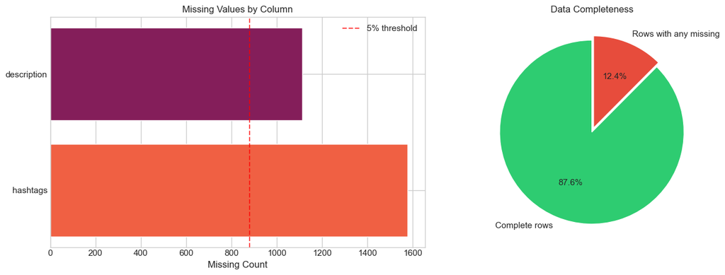

|  | Missing | Pct (%) |
| --- | --- | --- |
| hashtags | 1576 | 8.96 |
| description | 1112 | 6.32 |

```python
missing = df.isnull().sum()
missing_pct = (missing / len(df) * 100).round(2)
missing_df = pd.DataFrame({'Missing': missing, 'Pct (%)': missing_pct})
missing_df = missing_df[missing_df['Missing'] > 0].sort_values('Missing', ascending=False)

fig, axes = plt.subplots(1, 2, figsize=(14, 5))


if len(missing_df) > 0:
    bars = axes[0].barh(missing_df.index, missing_df['Missing'], color=sns.color_palette('rocket_r', len(missing_df)))
    axes[0].set_xlabel('Missing Count')
    axes[0].set_title('Missing Values by Column')
    axes[0].axvline(x=len(df)*0.05, color='red', linestyle='--', alpha=0.7, label='5% threshold')
    axes[0].legend()


    complete = df.dropna().shape[0]
    incomplete = len(df) - complete
    axes[1].pie([complete, incomplete], labels=['Complete rows', 'Rows with any missing'], autopct='%1.1f%%',
                colors=['#2ecc71', '#e74c3c'], explode=(0, 0.05), startangle=90)
    axes[1].set_title('Data Completeness')
else:
    axes[0].text(0.5, 0.5, 'No missing values', ha='center', va='center', fontsize=14)
    axes[1].text(0.5, 0.5, '100% Complete', ha='center', va='center', fontsize=14)

plt.tight_layout()
plt.show()

if len(missing_df) > 0:
    display(missing_df)
```

### EDA.ipynb — Code Cell 4

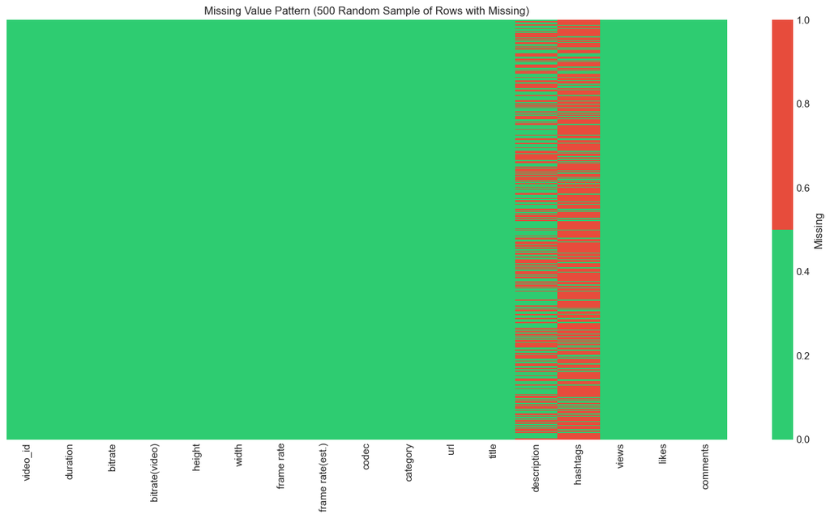

```python
from matplotlib.colors import ListedColormap
miss_cmap = ListedColormap(['#2ecc71', '#e74c3c'])
rows_with_missing = df[df.isnull().any(axis=1)]
if len(rows_with_missing) > 0 and len(rows_with_missing) <= 500:
    plt.figure(figsize=(14, min(8, len(rows_with_missing) * 0.02)))
    sns.heatmap(rows_with_missing.isnull(), cbar_kws={'label': 'Missing'}, cmap=miss_cmap, yticklabels=False)
    plt.title('Missing Value Pattern (Rows with Any Missing)')
    plt.tight_layout()
    plt.show()
elif len(rows_with_missing) > 500:
    sample = rows_with_missing.sample(500, random_state=42)
    plt.figure(figsize=(14, 8))
    sns.heatmap(sample.isnull(), cbar_kws={'label': 'Missing'}, cmap=miss_cmap, yticklabels=False)
    plt.title('Missing Value Pattern (500 Random Sample of Rows with Missing)')
    plt.tight_layout()
    plt.show()
```

### EDA.ipynb — Code Cell 5

```python
dup_video_id = df['video_id'].duplicated().sum()
dup_rows = df.duplicated().sum()

print(f"Duplicate video_id: {dup_video_id}")
print(f"Fully duplicate rows: {dup_rows}")

if dup_video_id > 0:
    dup_ids = df[df['video_id'].duplicated(keep=False)]['video_id'].value_counts().head(5)
    print(f"\nSample duplicate video_ids:\n{dup_ids}")
```

```
Duplicate video_id: 0
Fully duplicate rows: 0
```

### EDA.ipynb — Code Cell 6

```python
numeric_cols = ['duration', 'bitrate', 'bitrate(video)', 'height', 'width', 'frame rate', 'frame rate(est.)', 'views', 'likes', 'comments']
numeric_cols = [c for c in numeric_cols if c in df.columns]


stats = df[numeric_cols].describe().T
stats['skewness'] = df[numeric_cols].skew()
stats['kurtosis'] = df[numeric_cols].kurtosis()
stats['IQR'] = stats['75%'] - stats['25%']
stats['range'] = stats['max'] - stats['min']
stats.round(2)
```

|  | count | mean | std | min | 25% | 50% | 75% | max | skewness | kurtosis | IQR | range |
| --- | --- | --- | --- | --- | --- | --- | --- | --- | --- | --- | --- | --- |
| duration | 17589.0 | 241.55 | 493.03 | 1.00 | 51.0 | 135.00 | 268.00 | 2.584500e+04 | 16.96 | 601.82 | 217.00 | 2.584400e+04 |
| bitrate | 17589.0 | 1271.35 | 1375.36 | 0.00 | 437.0 | 743.00 | 1293.00 | 2.242100e+04 | 2.41 | 8.76 | 856.00 | 2.242100e+04 |
| bitrate(video) | 17589.0 | 1150.42 | 1351.80 | 0.00 | 326.0 | 632.00 | 1184.00 | 2.222900e+04 | 2.45 | 9.16 | 858.00 | 2.222900e+04 |
| height | 17589.0 | 766.78 | 467.29 | 108.00 | 426.0 | 640.00 | 960.00 | 2.592000e+03 | 1.12 | 0.47 | 534.00 | 2.484000e+03 |
| width | 17589.0 | 504.59 | 262.73 | 88.00 | 320.0 | 480.00 | 720.00 | 1.944000e+03 | 1.30 | 2.31 | 400.00 | 1.856000e+03 |
| frame rate | 17589.0 | 26.47 | 6.04 | 3.75 | 25.0 | 29.97 | 29.97 | 5.908000e+01 | -1.36 | 2.87 | 4.97 | 5.533000e+01 |
| frame rate(est.) | 17589.0 | 9.47 | 13.25 | 0.00 | 0.0 | 0.00 | 25.00 | 3.000000e+01 | 0.75 | -1.36 | 25.00 | 3.000000e+01 |
| views | 17589.0 | 68941.58 | 3537491.15 | 0.00 | 38.0 | 152.00 | 800.00 | 4.103849e+08 | 97.62 | 10655.63 | 762.00 | 4.103849e+08 |
| likes | 17589.0 | 208.86 | 8477.50 | 0.00 | 0.0 | 1.00 | 4.00 | 8.369810e+05 | 75.60 | 6440.81 | 4.00 | 8.369810e+05 |
| comments | 17589.0 | 12.90 | 225.84 | 0.00 | 0.0 | 0.00 | 1.00 | 1.663400e+04 | 49.28 | 3119.74 | 1.00 | 1.663400e+04 |

### EDA.ipynb — Code Cell 7

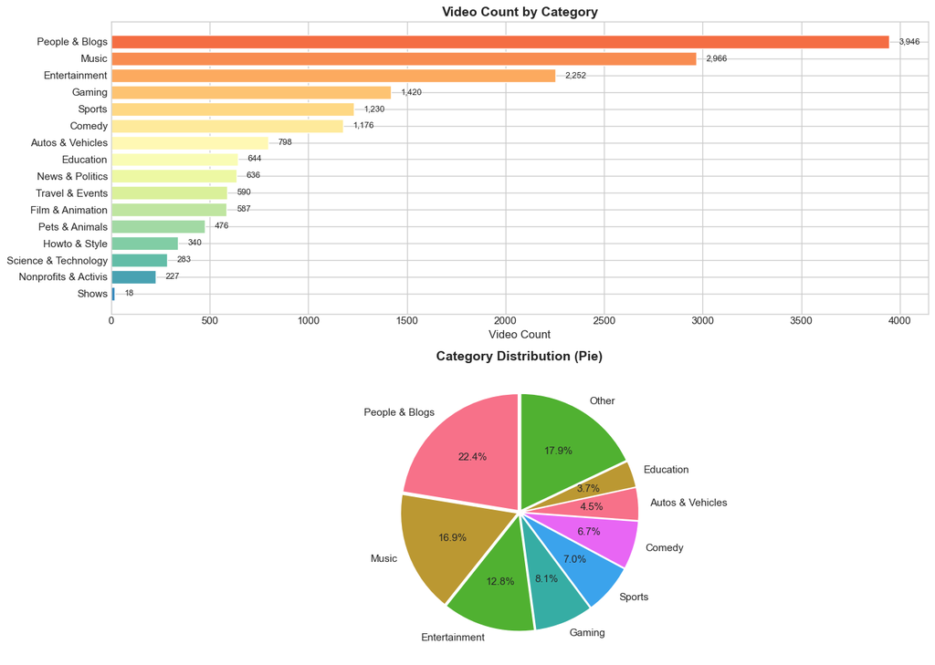

```python
fig, axes = plt.subplots(2, 1, figsize=(14, 10))


cat_counts = df['category'].value_counts()
colors = plt.cm.Spectral(np.linspace(0.2, 0.9, len(cat_counts)))
bars = axes[0].barh(cat_counts.index, cat_counts.values, color=colors)
axes[0].set_xlabel('Video Count')
axes[0].set_title('Video Count by Category', fontsize=14, fontweight='bold')
for i, (idx, val) in enumerate(zip(cat_counts.index, cat_counts.values)):
    axes[0].text(val + 50, i, f'{val:,}', va='center', fontsize=9)
axes[0].invert_yaxis()


top_n = 8
top_cats = cat_counts.head(top_n)
other_count = cat_counts.iloc[top_n:].sum() if len(cat_counts) > top_n else 0
pie_data = list(top_cats.values) + ([other_count] if other_count > 0 else [])
pie_labels = list(top_cats.index) + (['Other'] if other_count > 0 else [])
axes[1].pie(pie_data, labels=pie_labels, autopct='%1.1f%%', startangle=90, explode=[0.02]*len(pie_data))
axes[1].set_title('Category Distribution (Pie)', fontsize=14, fontweight='bold')

plt.tight_layout()
plt.show()
```

### Figure Interpretation

This plot shows how the featured variables vary in this section of the analysis. The main takeaway is the relative differences in level and spread across groups, which indicates meaningful signal for understanding and predicting virality.

### EDA.ipynb — Code Cell 8

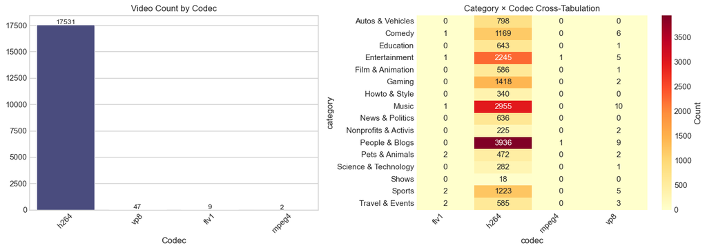

```python
fig, axes = plt.subplots(1, 2, figsize=(14, 5))


codec_counts = df['codec'].value_counts()
sns.barplot(x=codec_counts.index, y=codec_counts.values, ax=axes[0], palette='viridis')
axes[0].set_title('Video Count by Codec')
axes[0].set_xlabel('Codec')
axes[0].tick_params(axis='x', rotation=45)
for i, v in enumerate(codec_counts.values):
    axes[0].text(i, v + 50, str(v), ha='center', fontsize=10)


cross = pd.crosstab(df['category'], df['codec'])
sns.heatmap(cross, annot=True, fmt='d', cmap='YlOrRd', ax=axes[1], cbar_kws={'label': 'Count'})
axes[1].set_title('Category × Codec Cross-Tabulation')
plt.xticks(rotation=45, ha='right')
plt.yticks(rotation=0)
plt.tight_layout()
plt.show()
```

### Figure Interpretation

This plot shows how the featured variables vary in this section of the analysis. The main takeaway is the relative differences in level and spread across groups, which indicates meaningful signal for understanding and predicting virality.

### EDA.ipynb — Code Cell 9

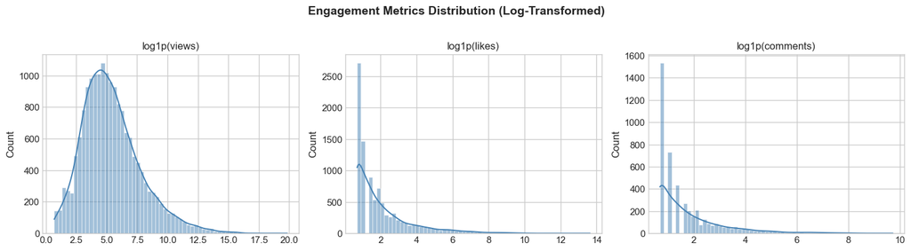

```python
eng_cols = ['views', 'likes', 'comments']
fig, axes = plt.subplots(1, 3, figsize=(15, 4))

for ax, col in zip(axes, eng_cols):
    data = np.log1p(df[col].replace(0, np.nan).dropna())
    sns.histplot(data, kde=True, ax=ax, bins=60, color='steelblue', edgecolor='white')
    ax.set_title(f'log1p({col})')
    ax.set_xlabel('')

plt.suptitle('Engagement Metrics Distribution (Log-Transformed)', fontsize=14, fontweight='bold', y=1.02)
plt.tight_layout()
plt.show()
```

### EDA.ipynb — Code Cell 10

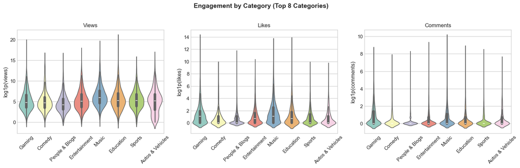

```python
top_categories = df['category'].value_counts().head(8).index.tolist()
df_top = df[df['category'].isin(top_categories)].copy()
df_top['log_views'] = np.log1p(df_top['views'])

fig, axes = plt.subplots(1, 3, figsize=(16, 5))

for ax, col, log_col in zip(axes, ['views', 'likes', 'comments'], ['log_views', None, None]):
    if log_col and col == 'views':
        sns.violinplot(data=df_top, x='category', y='log_views', ax=ax, palette='Set3')
        ax.set_ylabel('log1p(views)')
    else:
        y_vals = np.log1p(df_top[col])
        plot_df = df_top.assign(log_val=y_vals)
        sns.violinplot(data=plot_df, x='category', y='log_val', ax=ax, palette='Set3')
        ax.set_ylabel(f'log1p({col})')
    ax.set_title(col.title())
    ax.tick_params(axis='x', rotation=45)
    ax.set_xlabel('')

plt.suptitle('Engagement by Category (Top 8 Categories)', fontsize=14, fontweight='bold', y=1.02)
plt.tight_layout()
plt.show()
```

### Figure Interpretation

This figure highlights the distribution and variability of the plotted features. Differences across groups and the presence of outliers suggest non-uniform behavior that can inform feature importance and model performance.

### EDA.ipynb — Code Cell 11

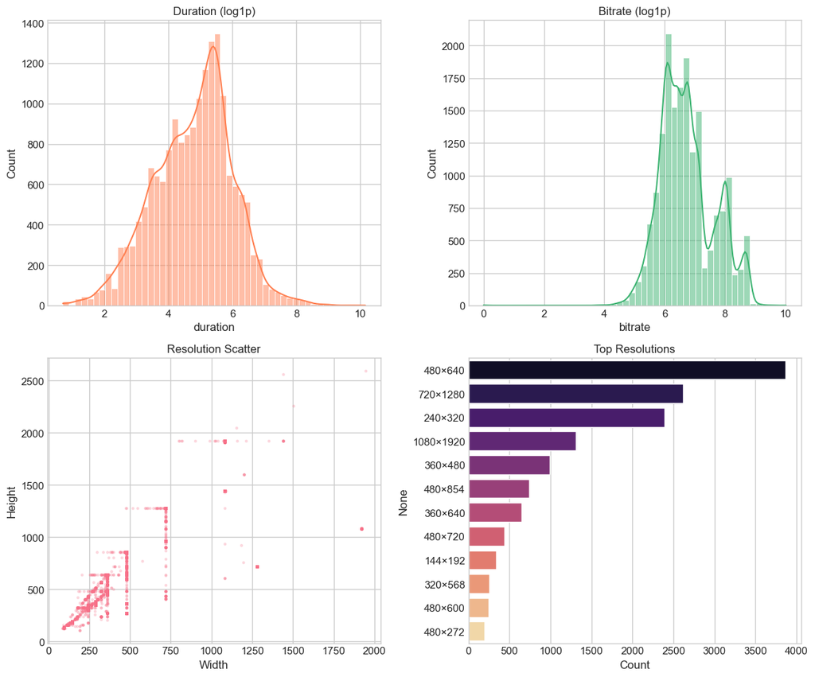

```python
fig, axes = plt.subplots(2, 2, figsize=(12, 10))

sns.histplot(np.log1p(df['duration']), kde=True, ax=axes[0,0], bins=50, color='coral')
axes[0,0].set_title('Duration (log1p)')

sns.histplot(np.log1p(df['bitrate']), kde=True, ax=axes[0,1], bins=50, color='mediumseagreen')
axes[0,1].set_title('Bitrate (log1p)')

axes[1,0].scatter(df['width'], df['height'], alpha=0.2, s=5)
axes[1,0].set_xlabel('Width')
axes[1,0].set_ylabel('Height')
axes[1,0].set_title('Resolution Scatter')

res_label = df['width'].astype(str) + '×' + df['height'].astype(str)
res_counts = res_label.value_counts().head(12)
sns.barplot(y=res_counts.index, x=res_counts.values, ax=axes[1,1], palette='magma')
axes[1,1].set_title('Top Resolutions')
axes[1,1].set_xlabel('Count')

plt.tight_layout()
plt.show()
```

### Figure Interpretation

This figure highlights the distribution and variability of the plotted features. Differences across groups and the presence of outliers suggest non-uniform behavior that can inform feature importance and model performance.

### EDA.ipynb — Code Cell 12

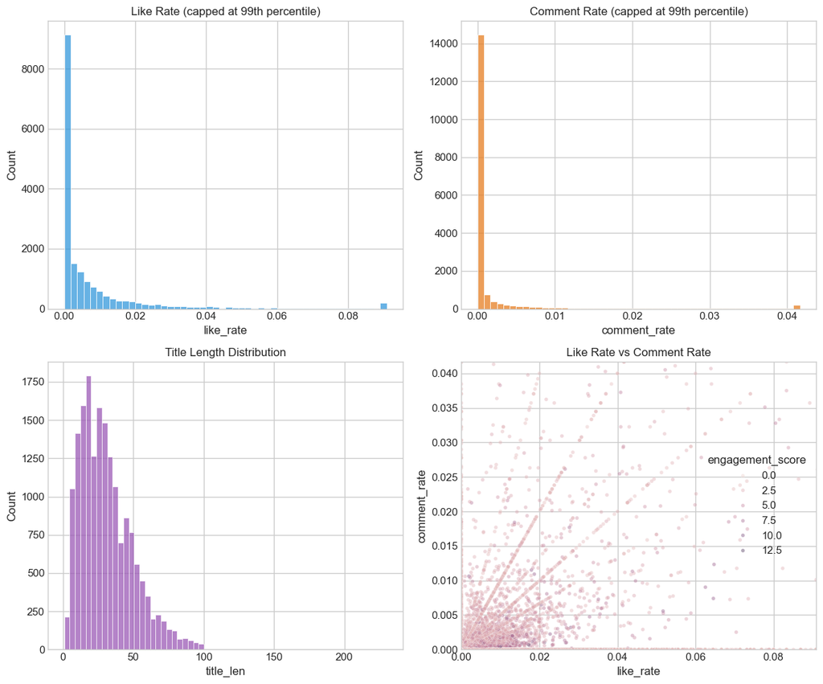

```python
df_eng = df.copy()
df_eng['like_rate'] = df_eng['likes'] / (df_eng['views'] + 1)
df_eng['comment_rate'] = df_eng['comments'] / (df_eng['views'] + 1)
df_eng['engagement_score'] = np.log1p(df_eng['likes'] + df_eng['comments'] * 2)
df_eng['title_len'] = df_eng['title'].fillna('').str.len()
df_eng['hashtag_count'] = df_eng['hashtags'].fillna('').apply(lambda x: len([h for h in str(x).split(',') if h.strip()]) if pd.notna(x) and str(x).strip() else 0)

fig, axes = plt.subplots(2, 2, figsize=(12, 10))

sns.histplot(df_eng['like_rate'].clip(upper=df_eng['like_rate'].quantile(0.99)), ax=axes[0,0], bins=50, color='#3498db')
axes[0,0].set_title('Like Rate (capped at 99th percentile)')

sns.histplot(df_eng['comment_rate'].clip(upper=df_eng['comment_rate'].quantile(0.99)), ax=axes[0,1], bins=50, color='#e67e22')
axes[0,1].set_title('Comment Rate (capped at 99th percentile)')

sns.histplot(df_eng['title_len'], ax=axes[1,0], bins=60, color='#9b59b6')
axes[1,0].set_title('Title Length Distribution')

sns.scatterplot(data=df_eng, x='like_rate', y='comment_rate', hue='engagement_score', alpha=0.4, ax=axes[1,1], s=15)
axes[1,1].set_xlim(0, df_eng['like_rate'].quantile(0.99))
axes[1,1].set_ylim(0, df_eng['comment_rate'].quantile(0.99))
axes[1,1].set_title('Like Rate vs Comment Rate')

plt.tight_layout()
plt.show()
```

### Figure Interpretation

This figure highlights the distribution and variability of the plotted features. Differences across groups and the presence of outliers suggest non-uniform behavior that can inform feature importance and model performance.

### EDA.ipynb — Code Cell 13

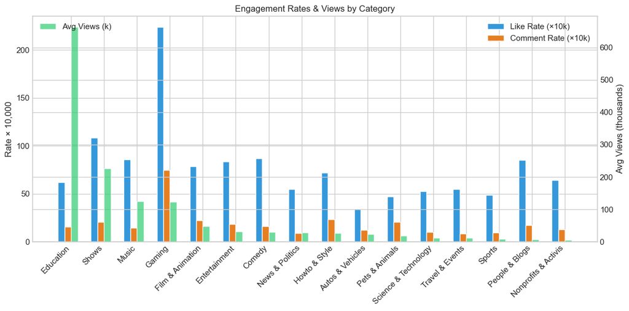

```python
rate_by_cat = df_eng.groupby('category').agg({
    'like_rate': 'mean',
    'comment_rate': 'mean',
    'views': 'mean',
    'engagement_score': 'mean'
}).round(6)
rate_by_cat.columns = ['Avg Like Rate', 'Avg Comment Rate', 'Avg Views', 'Avg Engagement']
rate_by_cat = rate_by_cat.sort_values('Avg Views', ascending=False)

fig, ax = plt.subplots(figsize=(12, 6))
x = np.arange(len(rate_by_cat))
w = 0.2
ax.bar(x - 1.5*w, rate_by_cat['Avg Like Rate']*10000, width=w, label='Like Rate (×10k)', color='#3498db')
ax.bar(x - 0.5*w, rate_by_cat['Avg Comment Rate']*10000, width=w, label='Comment Rate (×10k)', color='#e67e22')
ax2 = ax.twinx()
ax2.bar(x + 0.5*w, rate_by_cat['Avg Views']/1000, width=w, label='Avg Views (k)', color='#2ecc71', alpha=0.7)
ax.set_xticks(x)
ax.set_xticklabels(rate_by_cat.index, rotation=45, ha='right')
ax.set_ylabel('Rate × 10,000')
ax2.set_ylabel('Avg Views (thousands)')
ax.legend(loc='upper right')
ax2.legend(loc='upper left')
ax.set_title('Engagement Rates & Views by Category')
plt.tight_layout()
plt.show()
```

### Figure Interpretation

This figure highlights the distribution and variability of the plotted features. Differences across groups and the presence of outliers suggest non-uniform behavior that can inform feature importance and model performance.

### EDA.ipynb — Code Cell 14

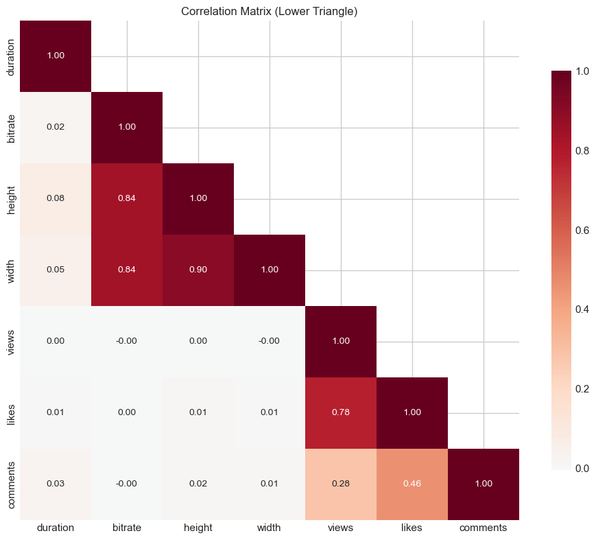

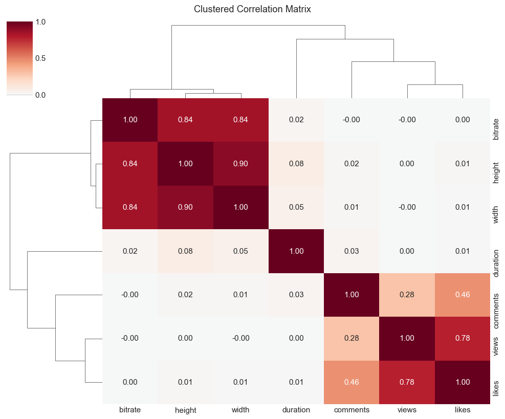

```python
corr_cols = ['duration', 'bitrate', 'height', 'width', 'views', 'likes', 'comments']
corr_cols = [c for c in corr_cols if c in df.columns]
corr_matrix = df[corr_cols].corr()


fig, ax = plt.subplots(figsize=(10, 8))
mask = np.triu(np.ones_like(corr_matrix, dtype=bool), k=1)
sns.heatmap(corr_matrix, mask=mask, annot=True, cmap='RdBu_r', center=0, fmt='.2f', square=True,
            ax=ax, cbar_kws={'shrink': 0.8}, annot_kws={'size': 10})
ax.set_title('Correlation Matrix (Lower Triangle)')
plt.tight_layout()
plt.show()


g = sns.clustermap(corr_matrix, annot=True, cmap='RdBu_r', center=0, fmt='.2f', figsize=(10, 8))
g.fig.suptitle('Clustered Correlation Matrix', y=1.02)
plt.show()
```

### EDA.ipynb — Code Cell 15

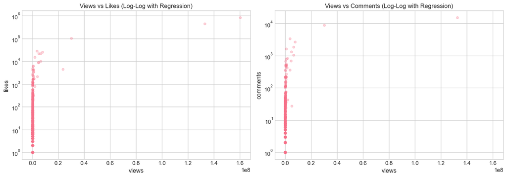

```python
fig, axes = plt.subplots(1, 2, figsize=(14, 5))

sample = df.sample(min(3000, len(df)), random_state=42)

sns.regplot(data=sample, x='views', y='likes', ax=axes[0], scatter_kws={'alpha': 0.3, 's': 20},
            line_kws={'color': 'red', 'lw': 2}, logx=True)
axes[0].set_yscale('log')
axes[0].set_title('Views vs Likes (Log-Log with Regression)')

sns.regplot(data=sample, x='views', y='comments', ax=axes[1], scatter_kws={'alpha': 0.3, 's': 20},
            line_kws={'color': 'red', 'lw': 2}, logx=True)
axes[1].set_yscale('log')
axes[1].set_title('Views vs Comments (Log-Log with Regression)')

plt.tight_layout()
plt.show()
```

### EDA.ipynb — Code Cell 16

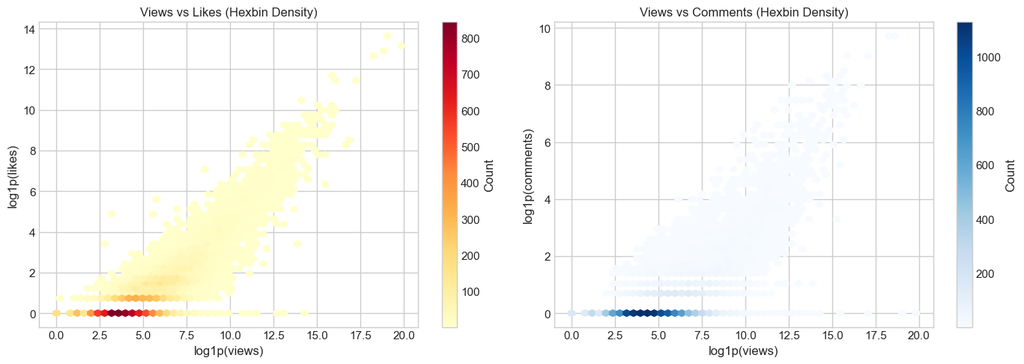

```python
fig, axes = plt.subplots(1, 2, figsize=(14, 5))

h1 = axes[0].hexbin(np.log1p(df['views']), np.log1p(df['likes']), gridsize=50, cmap='YlOrRd', mincnt=1)
plt.colorbar(h1, ax=axes[0], label='Count')
axes[0].set_xlabel('log1p(views)')
axes[0].set_ylabel('log1p(likes)')
axes[0].set_title('Views vs Likes (Hexbin Density)')

h2 = axes[1].hexbin(np.log1p(df['views']), np.log1p(df['comments']), gridsize=50, cmap='Blues', mincnt=1)
plt.colorbar(h2, ax=axes[1], label='Count')
axes[1].set_xlabel('log1p(views)')
axes[1].set_ylabel('log1p(comments)')
axes[1].set_title('Views vs Comments (Hexbin Density)')

plt.tight_layout()
plt.show()
```

### EDA.ipynb — Code Cell 17

```python
def count_outliers_iqr(series):
    Q1, Q3 = series.quantile(0.25), series.quantile(0.75)
    IQR = Q3 - Q1
    low, high = Q1 - 1.5*IQR, Q3 + 1.5*IQR
    return ((series < low) | (series > high)).sum()

outlier_counts = pd.DataFrame({
    'Column': ['views', 'likes', 'comments', 'duration'],
    'Outliers (IQR)': [count_outliers_iqr(df[c]) for c in ['views', 'likes', 'comments', 'duration']],
    'Pct (%)': [(count_outliers_iqr(df[c])/len(df)*100).round(2) for c in ['views', 'likes', 'comments', 'duration']]
})
outlier_counts
```

|  | Column | Outliers (IQR) | Pct (%) |
| --- | --- | --- | --- |
| 0 | views | 2888 | 16.42 |
| 1 | likes | 2565 | 14.58 |
| 2 | comments | 2424 | 13.78 |
| 3 | duration | 1376 | 7.82 |

### EDA.ipynb — Code Cell 18

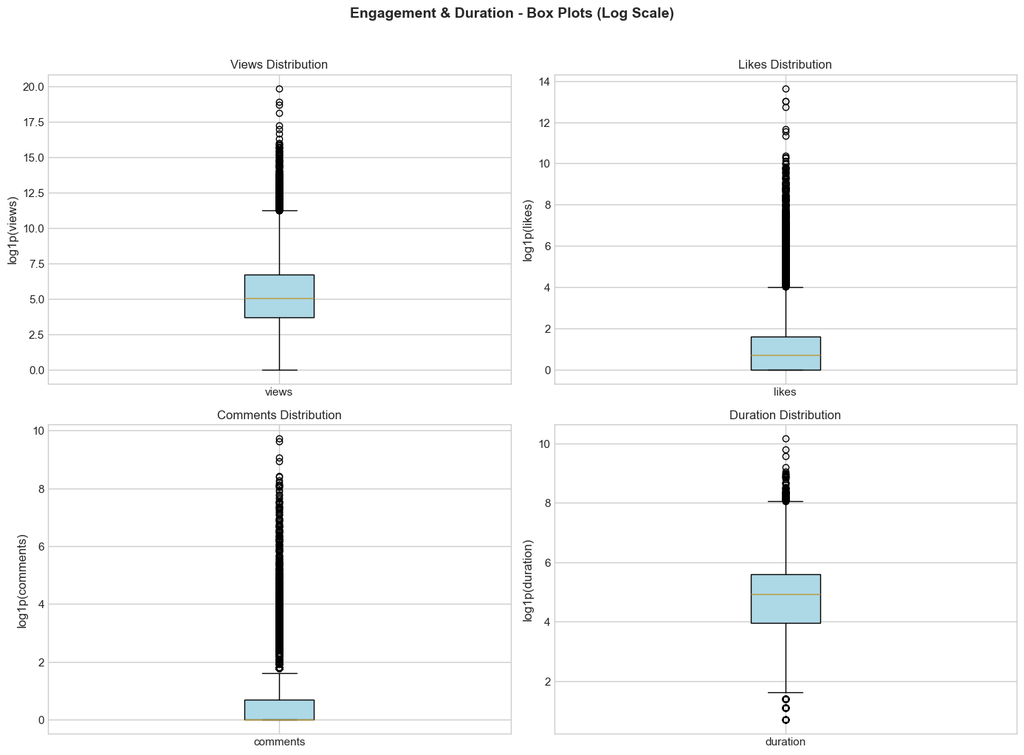

```python
fig, axes = plt.subplots(2, 2, figsize=(14, 10))

for ax, col in zip(axes.flat, ['views', 'likes', 'comments', 'duration']):
    data = np.log1p(df[col])
    bp = ax.boxplot([data], patch_artist=True)
    bp['boxes'][0].set_facecolor('lightblue')
    ax.set_ylabel(f'log1p({col})')
    ax.set_title(f'{col.title()} Distribution')
    ax.set_xticklabels([col])

plt.suptitle('Engagement & Duration - Box Plots (Log Scale)', fontsize=14, fontweight='bold', y=1.02)
plt.tight_layout()
plt.show()
```

### Figure Interpretation

The chart summarizes comparative behavior across the plotted groups. The result suggests that group-level differences are substantial, which supports using these variables for segmentation and predictive modeling.

### EDA.ipynb — Code Cell 19

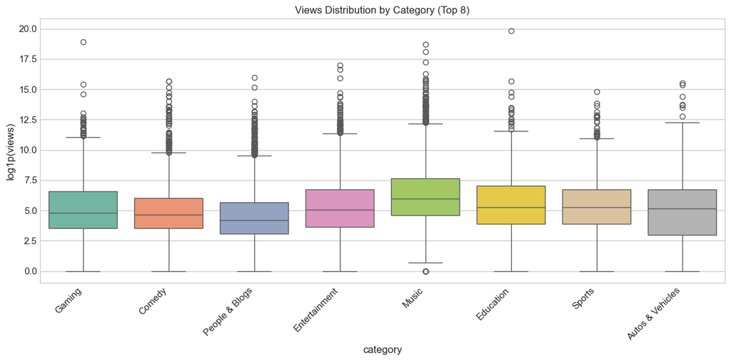

```python
top_categories = df['category'].value_counts().head(8).index.tolist()
df_top = df[df['category'].isin(top_categories)].copy()
df_top['log_views'] = np.log1p(df_top['views'])

plt.figure(figsize=(12, 6))
sns.boxplot(data=df_top, x='category', y='log_views', palette='Set2')
plt.xticks(rotation=45, ha='right')
plt.ylabel('log1p(views)')
plt.title('Views Distribution by Category (Top 8)')
plt.tight_layout()
plt.show()
```

### Figure Interpretation

The chart summarizes comparative behavior across the plotted groups. The result suggests that group-level differences are substantial, which supports using these variables for segmentation and predictive modeling.

### EDA.ipynb — Code Cell 20

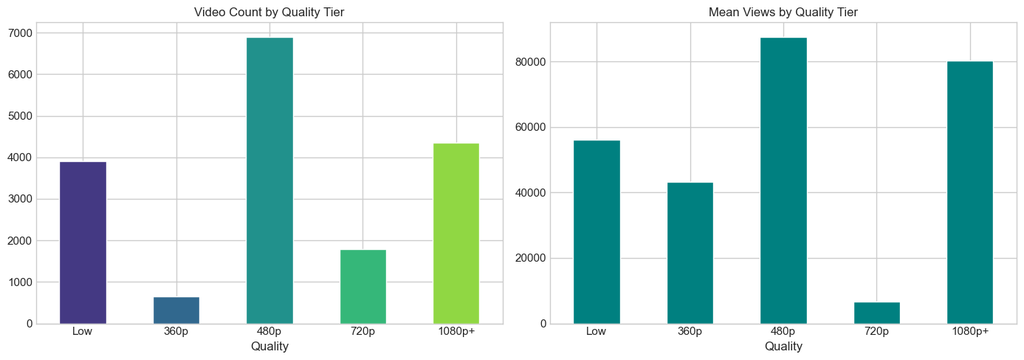

```python
df_res = df.copy()
df_res['aspect_ratio'] = df_res['width'] / (df_res['height'] + 1e-6)
df_res['pixels'] = df_res['width'] * df_res['height']

def quality_tier(row):
    w, h = row['width'], row['height']
    if w >= 1920 or h >= 1080: return '1080p+'
    if w >= 1280 or h >= 720: return '720p'
    if w >= 854 or h >= 480: return '480p'
    if w >= 640 or h >= 360: return '360p'
    return 'Low'

df_res['quality_tier'] = df_res.apply(quality_tier, axis=1)

fig, axes = plt.subplots(1, 2, figsize=(14, 5))

quality_order = ['Low', '360p', '480p', '720p', '1080p+']
qt_counts = df_res['quality_tier'].value_counts().reindex(quality_order).dropna()
if len(qt_counts) > 0:
    qt_counts.plot(kind='bar', ax=axes[0], color=sns.color_palette('viridis', len(qt_counts)))
axes[0].set_title('Video Count by Quality Tier')
axes[0].set_xlabel('Quality')
axes[0].tick_params(axis='x', rotation=0)

mean_views_qt = df_res.groupby('quality_tier')['views'].mean().reindex(quality_order).dropna()
if len(mean_views_qt) > 0:
    mean_views_qt.plot(kind='bar', ax=axes[1], color='teal')
axes[1].set_title('Mean Views by Quality Tier')
axes[1].set_xlabel('Quality')
axes[1].tick_params(axis='x', rotation=0)

plt.tight_layout()
plt.show()
```

### Figure Interpretation

This visualization emphasizes differences in the outcome and predictor distributions across categories. The key result is that category-specific patterns are visible, indicating that category context is relevant for interpretation and modeling.